# DATASCI 385 - Experimental Methods

Lecture 04 - Selection Bias, Variability, and Regression Analysis

Danilo Freire

danilo.freire@emory.edu

Department of Data and Decision Sciences  
Emory University

# Hello, everyone! 👋 Nice to see you all again! 😉

# Brief recap 📚

## Last time, we saw that…

- Potential outcomes framework help us understand treatment effects
- Fundamental problem of causal inference: we only see one potential outcome
- Treatment effect is the difference between potential outcomes ($\tau_{i} = Y_{1,i} - Y_{0,i}$)
- Average causal effect is the goal, but simple means comparison is usually biased
- Selection bias: treated/untreated groups may differ even before treatment
- Bias does not vanish in large samples
- Mathematical expectation $E[Y]$ is the population average
- Law of large numbers: sample average converges to population average
- Conditional expectation $E[Y_i|X_i]$ is the average outcome given $X_i$
- SUTVA (Stable Unit Treatment Value Assumption)
- Violations of SUTVA: spillovers, contamination
- External validity: generalising results to other settings
- Heterogeneous treatment effects: effects vary across units
- Compliance problem: people may not follow random assignment
- Intent-to-Treat (ITT) analyses address compliance

## Today, we will discuss…

- A little more about potential outcomes
- Measuring variability
- Different types of selection bias, e.g.:
  - Inappropriate controls
  - Loss to follow-up
  - Attrition bias
  - Survivorship bias
  - Post-treatment bias
- How to use `R` and `DeclareDesign` to estimate regression models
- But first…

[figure not shown]

Source: [xkcd](https://xkcd.com/2618/) (who else? 😄)

## Funny correlation of the day!

[figure not shown]

# Let’s get started! 🚀

## Potential outcomes revisited

- Remember from last time: we have two potential outcomes for each unit
- We only observe one of them: $Y_i = Y_{1,i} \cdot D_i + Y_{0,i} \cdot (1 - D_i)$
  - $D_i$ is the treatment indicator = 1 if treated, 0 if not
- So we need to estimate the average treatment effect (ATE):
  - $E[Y_{1,i} - Y_{0,i}] = E[Y_{1,i}] - E[Y_{0,i}]$
- The problem is, not all comparisons are valid
- I mean, they can be, but only under the heroic assumption that the groups are similar on average before any adjustment
- Otherwise, we will have selection bias
- Let’s see how this works in practice! 🤓

## Khuzdar and Maria

- Selection bias occurs when the groups are systematically different before treatment
- Using an example from [Angrist and Pischke (2021)](https://www.masteringmetrics.com/), let’s say we have a student called Khuzdar from Kazakhstan, who is considering studying in the U.S. and is worried about the cold weather
- Should he get health insurance? 🤔
- Let’s imagine that, without insurance, Khuzdar has a potential outcome of $Y_{0,i} = 3$ and, with insurance, $Y_{1,i} = 4$. So the treatment effect is $\tau_i = 1$, that is, he gains 1 “health point” by getting insurance
- Now, let’s imagine that Khuzdar has a Chilean colleague called Maria Moreno, who is also considering studying in the U.S.
- But since she comes from chilly Santiago, she is not worried about the cold weather
- So, without insurance, Maria has a potential outcome of $Y_{0,i} = 5$ and, with insurance, $Y_{1,i} = 5$. So the treatment effect is $\tau_i = 0$, that is, she gains no “health points” by getting insurance

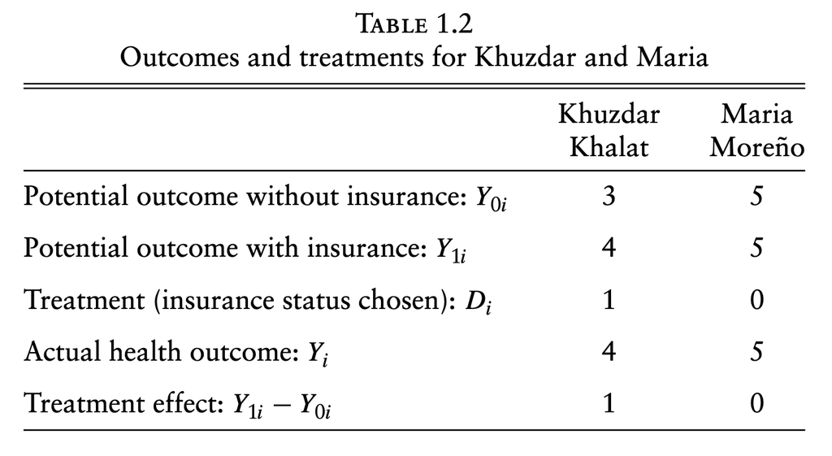

## Khuzdar and Maria

- In fact, the comparison between frail Khuzdar and hearty Maria tells us little about the causal effects of their choices!
- Why is that? Because they were different to begin with
- Imagine that Khuzdar got insurance and Maria did not
- Let’s do our mathematical trick again: we will add and subtract $Y_{0, Khuzdar}$ from the treatment effect (they cancel each other out, right?)
- So we have the following:

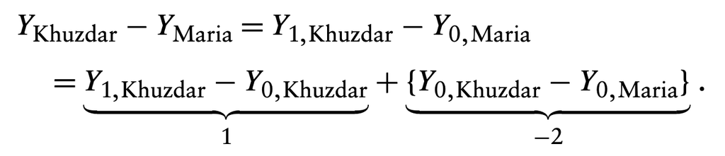

- What would be the result of this comparison? And what conclusion would we draw from it?

## Difference in means = average treatment effect + selection bias

- So far, so good? 🤓
- If we assume that the treatment has a constant effect (i.e., the treatment effect is the same for everyone), we can rewrite the equation as:

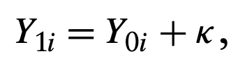

- Where $\kappa$ is both the individual and average causal effect of insurance on health. This is a simplifying assumption for this derivation; the core result holds even with varied effects
- Using the constant-effects model to substitute for $Avg_n[Y_{1i}|D_i = 1]$, we have

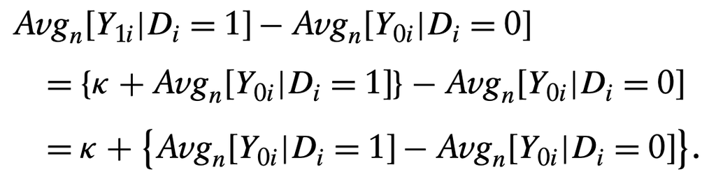

## How to check for selection bias?

### Balance tests

- We use balance tests or (randomisation checks) to check if the groups are similar before treatment
- The idea is to compare the means of the covariates for the treated and untreated groups
- If the means are similar, it provides evidence that nothing systematic is driving the treatment effect
- We are never 100% sure, but we trust the random assignment
- Small differences in means are acceptable, as long as they are not systematic
- Why? Because some variation can happen only by chance
- 100% personal opinion: I think they aren’t always useful… (can you guess why? 🤔)
- [Mutz et al. (2018)](https://www.tandfonline.com/doi/full/10.1080/00031305.2017.1322143) make a good case for that

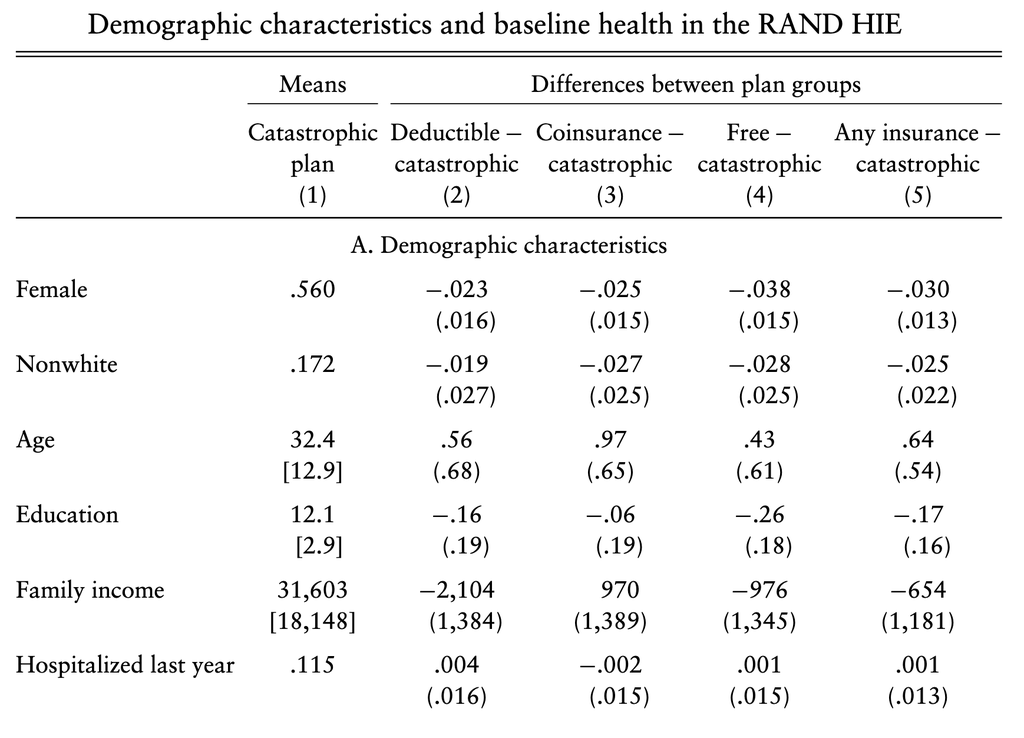

Angrist and Pischke (2021), pp. 20 (selected parts)

# Questions? 🤔

# Different types of selection bias 🎯

## Causal diagrams and associations

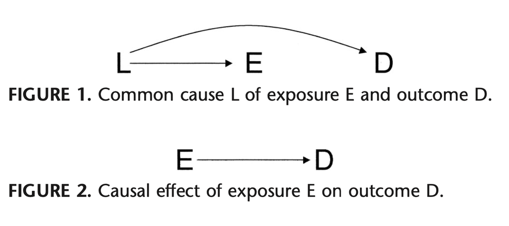

## Some sources of selection bias

### Losses to follow-up: The scenario

- A common problem in experiments is individuals dropping out before the study ends
- This is an issue because the treatment effect may be different for those who leave
- Example: A study on antiretroviral therapy for HIV-infected patients. Let’s define the variables:
  - **E (Exposure):** The antiretroviral therapy
  - **D (Disease):** The outcome, developing AIDS
  - **L (Measured):** Presence of other HIV symptoms (e.g., fever)
  - **U (Unmeasured):** True level of immunosuppression
  - **C (Censoring):** The patient drops out of the study ($C=1$)
- Patients with greater immunosuppression (**U**) are more likely to have symptoms (**L**) and are also more likely to drop out (**C**)

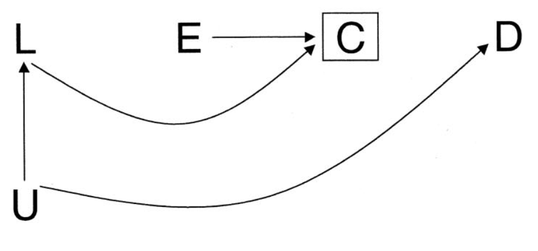

- The causal diagram shows the relationships between these variables
- The core problem is that dropping out (**C**) is related to both health factors and the final outcome

## Attrition bias

### Closely related to losses to follow-up

- Attrition bias is a type of selection bias that occurs when individuals drop out of a study in a way that is related to the treatment or outcome
- It is more systematic than losses to follow-up, which can happen by chance (e.g., disengagement, relocation, or other factors, leading to incomplete data)
- For example, in a clinical trial, if participants experiencing side effects disproportionately drop out of the treatment group compared to the placebo group, this difference introduces attrition bias
- In short, attrition bias specifically addresses the bias that arises when these departures are non-random
- As with losses to follow-up, this is a type of selection bias that can be caused by the experiment itself, not only by pre-existing differences between groups

## Survivorship bias

- In my view, one of the coolest examples of selection bias
- Survivorship bias is the logical error of concentrating on the people or things that made it past some selection process and overlooking those that did not
- It is also closely related to attrition and loss to follow-up bias (more commonly mentioned in observational data)
  - Attrition bias emphasises the process of losing data, while survivorship bias highlights the exclusion of failures in analysis
- For instance, imagine that you are studying the effect of education on income
- If you only look at people who have completed college, you are ignoring those who dropped out
- This can lead to an overestimation of the effect of education on income
- Why? Because those who dropped out may have done so because they were not good students, which can affect their income
- Have a look at this example (you may have seen it before!)

## Survivorship bias in World War II aircraft

- During World War II, the US military wanted to improve the armour on its aircraft
- They analysed the bullet holes on returning aircraft and decided to add more armour to the areas with the most bullet holes
- Considering the picture you see here, where would you add the armour?
- More [here](https://en.wikipedia.org/wiki/Survivorship_bias#Military)
- Another example: Imagine you are studying mutual fund performance, and you look at funds that are still in operation. You see that they beat the S&P 500 by 2% per year
- What’s the problem here?

[figure not shown]

## Post-treatment bias (or overcontrol)

- Post-treatment bias occurs when we control for a variable that is a *consequence* of the treatment
- This is a critical mistake because you are controlling away one of the causal pathways through which the treatment works
- **Example**: A job training programme
  - **Treatment (T):** The training programme
  - **Outcome (Y):** Finding employment
  - **Mediator (M):** Number of job applications submitted
- The training **(T)** works in two ways:
  1. **Directly:** It improves skills (T → Y)
  2. **Indirectly:** It motivates people to submit more applications **(M)**, which in turn leads to employment (T → M → Y)
- The number of applications is a post-treatment variable because it is caused by the training

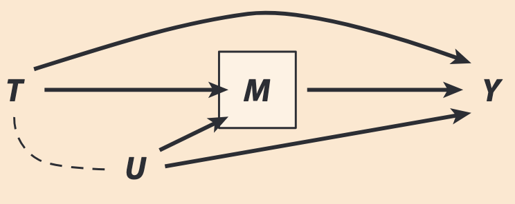

Source: [Elwert and Winship (2014)](https://www.annualreviews.org/content/journals/10.1146/annurev-soc-071913-043455)

- If we add the number of job applications **(M)** to our regression model, we are asking:
  - *“What is the effect of training, holding the number of applications constant?”*
- This blocks the indirect causal path. We are left with an underestimate of the programme’s total effect
- Is there a statistical fix? Not really!
- The solution is theoretical: think carefully about your causal model and do not control for mediators when you want to estimate the total effect

## Examples of post-treatment bias

### Avoidable post-treatment bias

- Causal effect of party ID on the vote
  - Do control for race
  - Do not control for voting intentions five minutes before voting
- Causal effect of race on salary in a firm
  - Do control for qualifications
  - Don’t control for position in the firm
- Causal effect of medicine on health
  - Do control for health prior to the treatment decision
  - Do not control for side effects or other medicines taken later

### Unavoidable post-treatment bias

- Causal effect of democratisation on civil war; do we control for GDP?
  - Yes, since GDP → democratisation we must control to avoid omitted variable bias
  - No, since democratisation → GDP, we would have post-treatment bias
- Causal effect of legislative effectiveness on state failure; do we control for trade openness?
  - Yes, since trade openness → legislative effectiveness, we must control to avoid omitted variable bias
  - No, since legislative effectiveness → trade openness, we would have post-treatment bias

## Now it’s your turn! 🤓

- I will list some factors and you tell me if they are likely to be sources of selection bias (and why)
  - Telephone random sampling
  - Ascertainment: when the investigator responsible for assessing the outcome of interest is also aware of the group assignment
  - [WEIRD samples](https://www.apa.org/monitor/2010/05/weird): Western, Educated, Industrialised, Rich, and Democratic
  - Referral filter: when the study population is recruited through referrals, often from health care providers or NGOs
  - When you ask socially sensitive questions in a survey

# Measuring variability 📏

## Measuring variability (part 1): Standard deviation

- Apart from averages, we are also interested in variability: how spread out is our data?
- The foundational measure is variance, the average squared deviation from the mean
- The sample variance of $Y_i$ in a sample of size $n$ is defined as:
  - $S(Y_i)^2 = \frac{1}{n-1} \sum_{i=1}^{n} (Y_i - \bar{Y})^2$
- Since variance is in squared units, we use its square root, the standard deviation (SD)
- The SD is a descriptive measure: it summarises the variability *within* your dataset
- Example: Suppose you measure the IQ of 50 students
  - You find the average IQ is $\bar{IQ} = 100$
  - You calculate the $SD = 15$
- What does this mean?
  - It describes the spread of IQs *in your sample*
  - “A typical student in your sample has an IQ that is about 15 points away from the sample average of 100”
  - It answers the question: “How much do the individual data points differ from each other?”

## Measuring variability (part 2): Standard error

- The standard error (SE) is different: it is the standard deviation of a statistic (like the sample mean)
- It measures how precise your sample mean is as an estimate of the true population mean
- The standard error of the sample mean is:
  - $SE(\bar{Y}) = \frac{\sigma(Y_i)}{\sqrt{n}}$
- Since we rarely know the population SD ($\sigma$), we use the sample SD ($S$) instead:
  - $SE(\bar{Y}) = \frac{S(Y_i)}{\sqrt{n}}$
- The SE is about precision and is used for inference (e.g., confidence intervals), while the SD is about the variability of the data
- Example: For the same 50 students with $\bar{IQ} = 100$ and $SD = 15$
  - The Standard Error (SE) is:
  - $SE = \frac{15}{\sqrt{50}} \approx 2.12$
- What does this mean?
  - It describes the precision of your *sample average*
  - “If you repeated the study with another 50 students, you would expect the new sample mean to be roughly 2.12 points away from the true population mean”
  - It answers the question: “How much would my sample average likely change if I took a new sample?”

## The standard error of a difference in means

### The concept: Precision of the treatment effect

- In an experiment, we don’t just care about one mean; we care about the difference in means ($\bar{Y}_{1} - \bar{Y}_{0}$)
- Just as each sample mean has its own precision (its SE), the difference between them also has a measure of precision
- The standard error of the difference tells us how much we’d expect our estimated treatment effect to vary if we repeated the experiment
- Analogy: Imagine trying to measure the height difference between two platforms, but both are a bit wobbly. The uncertainty in your final measurement comes from the wobbliness of *both* platforms
- The SE of the difference combines the uncertainty from both the treatment and control group means

### The formula & its use

- The uncertainty (variance) of a difference between two independent groups is the *sum* of their individual variances:
  - $Var(\bar{Y}_{1} - \bar{Y}_{0}) = Var(\bar{Y}_{1}) + Var(\bar{Y}_{0})$
- This leads to the formula for the standard error of the difference, which combines the variability ($S^2$) and sample size ($n$) from both groups:
  - $SE(\bar{Y}_{1} - \bar{Y}_{0})=\sqrt{\frac{S(Y_{1})^2}{n_{1}}+\frac{S(Y_{0})^2}{n_{0}}}$
- Why it’s crucial: This value is the foundation for hypothesis testing! It’s the denominator in a t-test:
  - $t = \frac{\text{Difference in means}}{\text{SE of the difference}}$, or $t = \frac{\bar{Y}_{1} - \bar{Y}_{0}}{SE(\bar{Y}_{1} - \bar{Y}_{0})}$
- It also determines the width of the confidence interval around our treatment effect
- While your software computes this for you 🤖, knowing what’s “under the hood” helps you interpret your results! 😉

# Regression analysis of experiments 📊

## Regression analysis of experiments

- It is super easy to estimate the average treatment effect using regression analysis
- Although some areas (e.g. medicine, psychology) often use $t$-tests for difference-in-means, regression is more flexible and gives you exactly the same results
- The idea is to regress the outcome variable on the treatment variable and some covariates if necessary
- But always report the ATE without covariates first, as it is the most interpretable
- Let’s see an example using `R`! 🤓
- We will use the `fabricatr`, `estimatr`, and `randomizr` packages, which are part of the `DeclareDesign` suite
- More information about the packages is available [here](https://declaredesign.org/r/fabricatr/index.html), [here](https://declaredesign.org/r/randomizr/index.html), and [here](https://declaredesign.org/r/estimatr/index.html)
- We will start slowly, don’t worry, and build up from there in the next lectures 😉

## Simulating data in `R`

- Imagine that we want to estimate the effect of a job training programme on the number of interviews that unemployed individuals get, similar to the example we discussed earlier
- The treatment variable is `treat`, which takes the value 1 if the individual received the training and 0 otherwise
- We will assign 1000 individuals to the treatment and control groups, with an equal probability of being assigned to each group (simple random assignment)
- The outcome variable is `interviews`, which is the number of interviews the individual got after the training
- The treatment effect is 5, that is, individuals who received the training got 5 more interviews than those who did not

```r
# Load the required packages
library(fabricatr)
library(estimatr)
library(randomizr)

# Set the seed for reproducibility
set.seed(385)

# Simulate the data
data <- fabricate( # fabricatr
  N = 1000, # base
  treat = simple_ra(N, prob = 0.5), # randomizr
  interviews = round(rnorm(N, mean = 10, sd = 2) + 5 * treat, digits = 0) # base
)

# Check the first few rows of the data
head(data)
```

```
    ID treat interviews
1 0001     1         13
2 0002     0          8
3 0003     1         15
4 0004     1         17
5 0005     0         12
6 0006     1         15
```

## Step-by-step: using `fabricatr` to simulate data

- We used the `fabricate()` function from the `fabricatr` package to simulate the data
- The package is very flexible and was built for all types of data simulations, mainly those used by social scientists (e.g. experiments, surveys)
  - We can draw from Likert scales, create binary variables, ordinal variables, categorical variables, etc
  - More about how to create different types of variables [here](https://declaredesign.org/r/fabricatr/articles/common_social.html)
- The `fabricate()` function takes a series of arguments, which are the variables we want to simulate
- It uses base `R` functions too, which makes it easy to use
- For instance, `N = 1000` is the number of individuals in the sample and we created it using just base `R`
- To simulate the `interviews` variable, we used the `rnorm()` function to draw from a normal distribution with mean 10 and standard deviation 2
- We add 5 because it is the treatment effect
- As we cannot have a fraction of an interview, we used the `round()` function to round the number of interviews to the nearest integer (`digits = 0`)
- So far so good? 🤓

## Randomising treatment assignment

- We used `simple_ra()` for simple random assignment, which is a simple coin flip. The arguments are:
  - `N`: the number of individuals in the sample (required)
  - `prob`: the probability of being assigned to the treatment group (optional)
  - `prob_each`: the probability of being assigned to each treatment group (optional)
- We could have used the `complete_ra()` function from the `randomizr` package to randomise the treatment assignment
- The function has a few arguments:
  - `N`: the number of individuals in the sample (required)
  - `m`: the number of individuals assigned to the treatment group (optional)
  - `m_each`: the number of individuals assigned to each treatment group (optional)
- We could also use `block_ra()` for block random assignment, which is when we divide the sample into blocks and then randomise within each block
- `cluster_ra()` is used for cluster random assignment, which is when we randomise at the cluster level (e.g. schools, hospitals)
- Finally, `block_and_cluster_ra()` is used for block and cluster random assignment, which is a combination of the two
- We will discuss these functions in further detail in the next lectures 😉

## Estimating the treatment effect

- Now that we have the data, we can estimate the treatment effect using the `lm_robust()` function from the `estimatr` package
- The function is similar to the `lm()` function, but it uses robust standard errors, which are more appropriate for experiments
- Why? Because [robust standard errors correct for heteroskedasticity and clustering](https://declaredesign.org/r/estimatr/articles/mathematical-notes.html#lm_robust-notes)
- This is a free lunch: if your data is not heteroskedastic or clustered, the robust standard errors will be the same as the regular standard errors
- The function takes a formula as an argument, which is the outcome variable regressed on the treatment variable

```r
model <- lm_robust(interviews ~ treat, data = data)
summary(model)
```

```
Call:
lm_robust(formula = interviews ~ treat, data = data)

Standard error type:  HC2

Coefficients:
            Estimate Std. Error t value   Pr(>|t|) CI Lower CI Upper  DF
(Intercept)   10.008    0.08986  111.37  0.000e+00    9.832   10.184 998
treat          4.958    0.12922   38.37 1.353e-198    4.704    5.211 998

Multiple R-squared:  0.5961 ,   Adjusted R-squared:  0.5957
F-statistic:  1472 on 1 and 998 DF,  p-value: < 2.2e-16
```

## Difference in means

- For those who would like to estimate the difference in means using the `t.test()` function, we’ve got you covered! 😉
- `estimatr` also has a function that does that, called `difference_in_means()` (what a surprise! 😂)
- It is actually more flexible than the `t.test()` function, as it can handle unit-randomised, cluster-randomised, block-randomised, matched-pair randomised, and matched-pair clustered designs. More [here](https://declaredesign.org/r/estimatr/articles/getting-started.html#difference_in_means)
- Here is how to use it:

```r
difference_in_means(interviews ~ treat, data = data)
```

```
Design:  Standard
      Estimate Std. Error  t value      Pr(>|t|) CI Lower CI Upper       DF
treat 4.957518  0.1292176 38.36566 2.019047e-198 4.703948 5.211088 995.4296
```

- As you can see, the results are exactly the same as the regression model
- Just the output looks a little different, but the interpretation is the same
- Use whatever you feel more comfortable with! 😊

## Interpreting the results

- The output of the `summary()` function gives us the coefficient estimate of the treatment variable
- The intercept is `10.008`, which is the average number of interviews for the control group
- The coefficient of the treatment variable is `4.958`, which is the average treatment effect
- The standard error of the treatment effect is `0.129`, which is the standard error of the difference in means
- Our results are statistically significant at the 5% level, as the $p$-value is less than 0.05

```r
model <- lm_robust(interviews ~ treat, data = data)
summary(model)
```

```
Call:
lm_robust(formula = interviews ~ treat, data = data)

Standard error type:  HC2

Coefficients:
            Estimate Std. Error t value   Pr(>|t|) CI Lower CI Upper  DF
(Intercept)   10.008    0.08986  111.37  0.000e+00    9.832   10.184 998
treat          4.958    0.12922   38.37 1.353e-198    4.704    5.211 998

Multiple R-squared:  0.5961 ,   Adjusted R-squared:  0.5957
F-statistic:  1472 on 1 and 998 DF,  p-value: < 2.2e-16
```

- The `R^2` and its adjusted version are measures of the goodness-of-fit of the model
  - They are the proportion of the variance in the outcome variable explained by the model
- The `F` statistic is a test of the overall significance of the model
  - The null hypothesis is that all coefficients are zero
  - But as we see, the treatment variable is significant

## Including pre-treatment covariates in the model

- We can also include covariates in the model to increase precision
- In contrast with the treatment, the covariates have no causal interpretation, that is, they are not affected by the treatment
- Even with randomisation, there can be small imbalances in covariates between treatment and control groups, especially in small samples
- Including these covariates in the regression helps to adjust for any residual imbalances that may exist due to random chance, making the analysis more accurate
- Including covariates can also help bolster the credibility of the results by demonstrating that the treatment effect persists even after controlling for relevant variables
- But remember to include only pre-treatment covariates in the model, as post-treatment covariates can introduce bias
- Let’s simulate a new dataset with two pre-treatment covariates: `age` and `education`

```r
set.seed(385)

data2 <- fabricate(
  N = 1000,
  treat = complete_ra(N, m = 500),
  age = round(rnorm(N, mean = 30, sd = 5)),
  education = round(rnorm(N, mean = 12, sd = 2)),
  interviews = round(rnorm(N, mean = 10, sd = 2) + 5 * treat)
)

head(data2)
```

```
    ID treat age education interviews
1 0001     0  32        11          9
2 0002     1  30        13         16
3 0003     1  31        12         16
4 0004     1  33        13         15
5 0005     0  27        15          7
6 0006     0  33        12          9
```

## Estimating the second model

- We can add covariates to experimental models to increase precision
- The same way we do in any regression:
  - $Y_i = \alpha + \beta \text{T}_i + \gamma \text{X}_i + \epsilon_i$
- [Freedman (2008)](https://doi.org/10.1214/07-AOAS143) demonstrated that pre-treatment covariate adjustment may bias estimates of average treatment effects in small samples
  - In small samples, covariates and treatment assignment may not be perfectly independent
- [Lin (2013)](https://doi.org/10.1214/12-AOAS583) proposed that if covariate correlations differ between treatment and control groups, centring and interacting covariates with the treatment variable will balance the groups
- This adjusts for covariates separately in each group, which is equivalent to including treatment-by-covariate interactions
  - $Y_i = \alpha + \beta \text{T}_i + \gamma \text{W}_i + \delta \text{T}_i \times \text{W}_i + \epsilon_i$
  - Where $W_i = \text{X}_i - \bar{\text{X}}$ and $\bar{\text{X}}$ is the mean of $\text{X}_i$
  - For ease of interpretation, we can centre the covariates to have a mean of zero
- Anyway, worry not! 😅 Our friends at [DeclareDesign](https://declaredesign.org/r/estimatr/articles/getting-started.html#lm_lin) have done all the work for us and created a function called `lm_lin()` that does everything automatically!

## Estimating the second model

```r
model2 <- lm_lin(interviews ~ treat,
                covariates = ~ age + education,
                data = data2)
summary(model2)
```

```
Call:
lm_lin(formula = interviews ~ treat, covariates = ~age + education,
    data = data2)

Standard error type:  HC2

Coefficients:
                  Estimate Std. Error  t value   Pr(>|t|)  CI Lower CI Upper
(Intercept)        9.88659    0.09213 107.3127  0.000e+00  9.705804 10.06738
treat              5.13084    0.12546  40.8956 3.281e-215  4.884642  5.37704
age_c              0.02845    0.01771   1.6062  1.085e-01 -0.006307  0.06320
education_c       -0.04550    0.04721  -0.9636  3.355e-01 -0.138150  0.04716
treat:age_c       -0.03324    0.02546  -1.3054  1.921e-01 -0.083206  0.01673
treat:education_c  0.04324    0.06140   0.7043  4.814e-01 -0.077248  0.16373
                   DF
(Intercept)       994
treat             994
age_c             994
education_c       994
treat:age_c       994
treat:education_c 994

Multiple R-squared:  0.6272 ,   Adjusted R-squared:  0.6254
F-statistic: 344.4 on 5 and 994 DF,  p-value: < 2.2e-16
```

## Sub-group analysis

- We can also estimate the treatment effect for sub-groups of the population
- This is useful when we suspect that the treatment effect may vary across known dimensions
- For instance, we can estimate the treatment effect for people with high and low levels of education
- We can do this by including an interaction term between the treatment variable and the covariate of interest
- We will discuss this in further detail in the next lectures, but here is how to do it

```r
# Create a binary subgroup (e.g., "high" vs. "low" education)
data2$high_edu <- ifelse(data2$education > median(data2$education), 1, 0)

# Fit an interaction model with covariates
model_interaction <- lm_robust(
  interviews ~ treat * high_edu + age + education,
  data = data2)

# Summarize results
summary(model_interaction)
```

```
Call:
lm_robust(formula = interviews ~ treat * high_edu + age + education,
    data = data2)

Standard error type:  HC2

Coefficients:
               Estimate Std. Error t value   Pr(>|t|) CI Lower CI Upper  DF
(Intercept)     9.39778    0.69048 13.6104  8.255e-39  8.04281 10.75275 994
treat           5.10068    0.16905 30.1726 1.682e-142  4.76894  5.43241 994
high_edu       -0.26179    0.24257 -1.0792  2.808e-01 -0.73780  0.21422 994
age             0.01141    0.01276  0.8938  3.716e-01 -0.01363  0.03644 994
education       0.02033    0.05026  0.4046  6.859e-01 -0.07829  0.11895 994
treat:high_edu  0.09721    0.25093  0.3874  6.985e-01 -0.39521  0.58962 994

Multiple R-squared:  0.6269 ,   Adjusted R-squared:  0.625
F-statistic: 341.1 on 5 and 994 DF,  p-value: < 2.2e-16
```

## Sub-group analysis: interpreting the results

- The output of the `summary()` function gives us the coefficient estimate of the treatment variable for the high education group
  - It is in the last line, `treat:high_edu`
- Interpretation: The treatment effect for the high-education subgroup (`high_edu = 1`) is 0.097 larger than for the low-education subgroup
- Total treatment effect for `high_edu = 1`: 5.101 + 0.097 = 5.198
- Significance: The interaction is not significant (CI: -0.395 to 0.590), meaning there’s no evidence the treatment effect differs between education subgroups
- This is expected, as we simulated the data to have the same treatment effect for all individuals (5)
- But it is good to know how to do it, right? 😉

```r
# Create a binary subgroup (e.g., "high" vs. "low" education)
data2$high_edu <- ifelse(data2$education > median(data2$education), 1, 0)

# Fit an interaction model with covariates
model_interaction <- lm_robust(
  interviews ~ treat * high_edu + age + education,
  data = data2)

# Summarize results
summary(model_interaction)
```

```
Call:
lm_robust(formula = interviews ~ treat * high_edu + age + education,
    data = data2)

Standard error type:  HC2

Coefficients:
               Estimate Std. Error t value   Pr(>|t|) CI Lower CI Upper  DF
(Intercept)     9.39778    0.69048 13.6104  8.255e-39  8.04281 10.75275 994
treat           5.10068    0.16905 30.1726 1.682e-142  4.76894  5.43241 994
high_edu       -0.26179    0.24257 -1.0792  2.808e-01 -0.73780  0.21422 994
age             0.01141    0.01276  0.8938  3.716e-01 -0.01363  0.03644 994
education       0.02033    0.05026  0.4046  6.859e-01 -0.07829  0.11895 994
treat:high_edu  0.09721    0.25093  0.3874  6.985e-01 -0.39521  0.58962 994

Multiple R-squared:  0.6269 ,   Adjusted R-squared:  0.625
F-statistic: 341.1 on 5 and 994 DF,  p-value: < 2.2e-16
```

# Cool, isn’t it? 😎

# Questions?

## Summary

- We discussed the potential outcomes framework in further detail, focusing on issues of selection bias
- We talked about different types of selection bias, such as inappropriate controls, loss to follow-up, attrition bias, survivorship bias, and confounders
- We also discussed how to measure variability using the standard deviation and standard error
- Then, we talked about regression analysis of experiments, including how to simulate data, randomise treatment assignment, estimate the treatment effect, and include pre-treatment covariates in the model
- We also introduced the `fabricatr`, `estimatr`, and `randomizr` packages, which are part of the `DeclareDesign` suite
- Finally, we discussed sub-group analysis and how to estimate the treatment effect for different sub-groups of the population
- I hope you enjoyed the lecture! 🤓
- Next time, we will discuss more about hypothesis testing and confidence intervals, so stay tuned! 😉

[figure not shown]

# Thank you and see you soon! 😃